# Complex Function Week 3

## Peter Ma | Aug 15 2020

This is the homework assignment for the problem set 1.19. I had drawn the answers and then decided to code them into a jupyter notebook since I'm pretty familiar with programing :)

I drew each first and with a rationale then I coded the representation in python.

### **Problem 1.19**

Draw nice pictures and write a sentence or two explaining the effect of the function $h$ from Example $1.20$ on the following lines in the complex plane: $$h(x + iy) = e^x(\cos(y) + i \sin(y))$$

**(a)** the real axis

**(b)** the imaginary axis

**(c)** the line $x = y$

**(d)** the line $x = 2y$

**(e)** the line $x = -y$

## Graphing Function

Here I just imported and created a function using matplotlib to help me graph these complex values generated by a complex function. Nothing fancy just some graphical changes.

```python
%matplotlib inline
import math
import matplotlib.pyplot as plt
import numpy as np

def plot_complex_number(z,x_min,x_max,y_min,y_max, dot_size=10):
    fig = plt.figure()
    fig.set_size_inches(18.5, 10.5)
    ax = plt.gca()

    ax.spines['left'].set_position('zero')
    ax.spines['right'].set_color('none')
    ax.spines['bottom'].set_position('zero')
    ax.spines['top'].set_color('none')

    b = [z.real,z.imag]

    ax = plt.axes()

    plt.scatter(a[0],a[1],color='red',s=dot_size)
    plt.scatter(b[0],b[1],color='red',s=dot_size)

    plt.axis('square')

    ax.text(0, y_max+0.5, r'Img', fontsize=10, horizontalalignment='center')
    ax.text(x_max+0.5, 0, r'Real', fontsize=10, verticalalignment='center')

    plt.xlim(x_min,x_max)
    plt.ylim(y_min,y_max)

    plt.grid(True,linestyle='--')

    plt.show()
```

# Part A

Graph the real axis with the $h(x + iy) = e^x(\cos(y) + i \sin(y))$

First I create the real axis that are the inputs. With the `get_input_real_axis`

Then I create the function `get_output_function` $h(x + iy) = e^{x+iy}$ which is the same as $e^x(\cos(y) + i \sin(y))$

Here is my first attempted drawings. This makes sense as it'll just be like any other expoential function in the real domain. The one's we've seen in high school. In this case scenario we get the following.

$$e^x(\cos(y) + i \sin(y)) = e^x$$

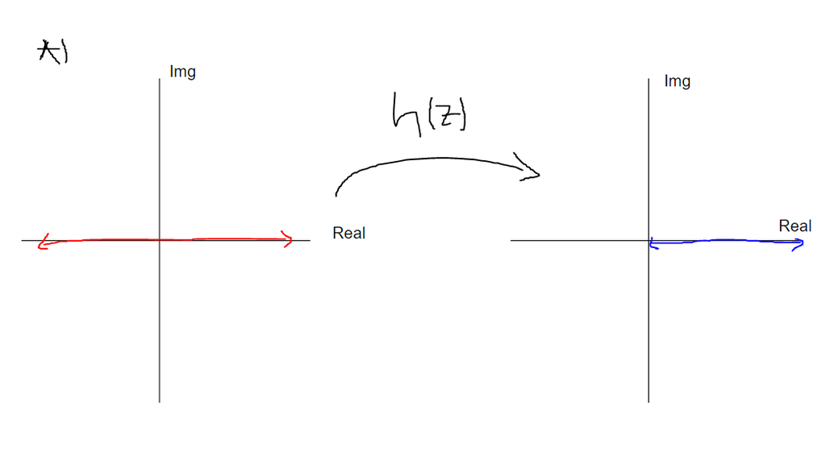

```python
from IPython.display import Image
Image('/content/a_question.PNG')
```

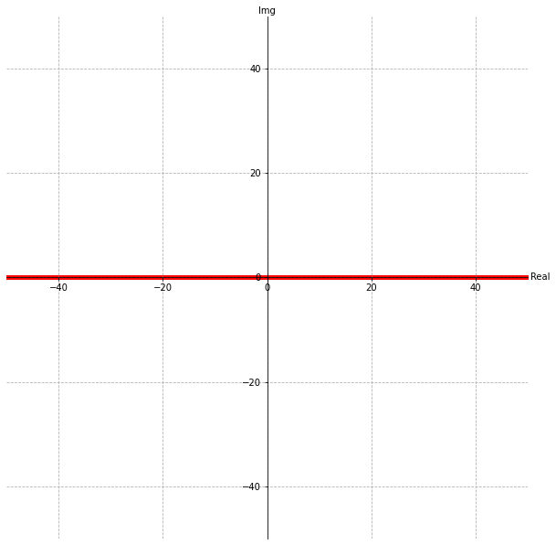

```python
min = -80
max = 80
dx = 1000
def get_input_real_axis(min, max, dx=dx):
  a = np.zeros(((max-min)*dx), dtype=complex)
  for i in range(a.shape[0]):

    x_val = i/dx+min
    # Imaginary part is always zero
    y_val = 0

    complex_number = x_val + 1j*y_val
    if complex_number.imag!=0:
      print(complex_number)

    a[i] = complex_number
  return a

a = get_input_real_axis(min = min, max = max )

plot_complex_number(a, -50, 50, -50, 50)
```

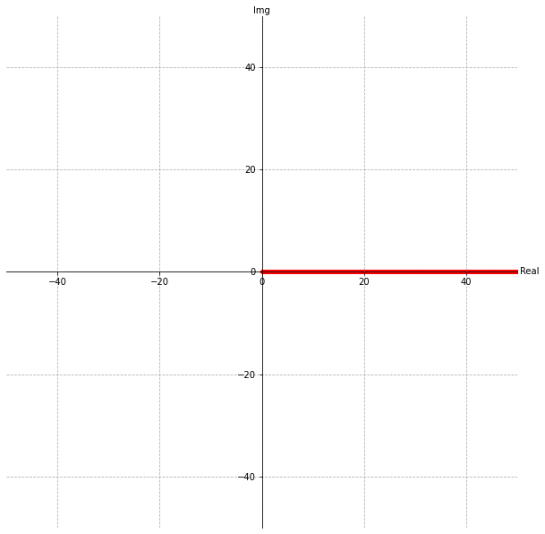

```python
def get_output_function(a):
  b = np.zeros(a.shape, dtype=complex)
  for i in range(a.shape[0]):
    real_part = a[i].real
    imag_part = a[i].imag
    # Here I wrote the function from the previous description above
    b[i] = math.e**(real_part+1j*imag_part)
  return b
b = get_output_function(a)
plot_complex_number(b, -50, 50, -50, 50)
```

# Part B

Graph the imaginary axis with the $h(x + iy) = e^x(\cos(y) + i \sin(y))$

First I create the real axis that are the inputs. With the `get_input_imag_axis`

Then I create the function `get_output_function` $h(x + iy) = e^{x+iy}$ which is the same as $e^x(\cos(y) + i \sin(y))$

Below was my attempt to first draw the graph. Since it's just the imaginary part $x=0$ we get $h(z) = e^{iy}$ which we are familiar with as it traces the unit circle. $$e^x(\cos(y) + i \sin(y)) = e^{iy}$$

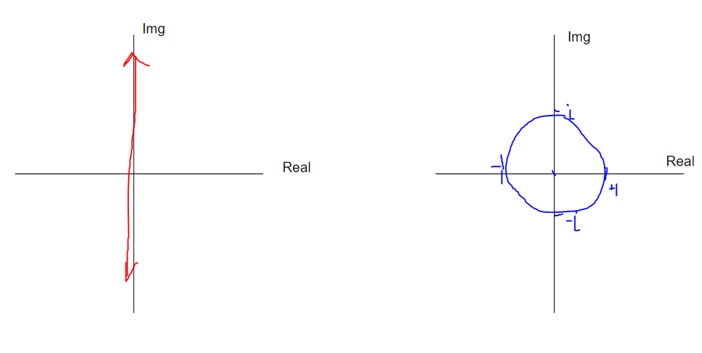

```python
from IPython.display import Image
Image('/content/b_question.PNG')
```

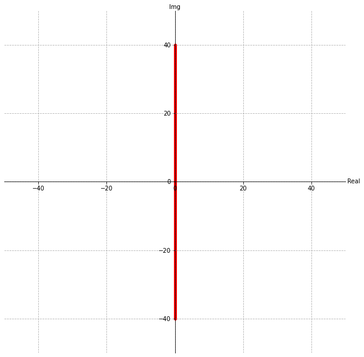

```python
min = -40
max = 40
def get_input_imag_axis(min, max, dx =1000):
  a = np.zeros(((max-min)*dx), dtype=complex)
  for i in range(a.shape[0]):
    x_val = 0
    # Imaginary part is always zero
    y_val = i/dx+min
    complex_number = x_val + 1j*y_val
    a[i] = complex_number
  return a
a = get_input_imag_axis(min = min, max = max )
plot_complex_number(a, -50, 50, -50, 50)
```

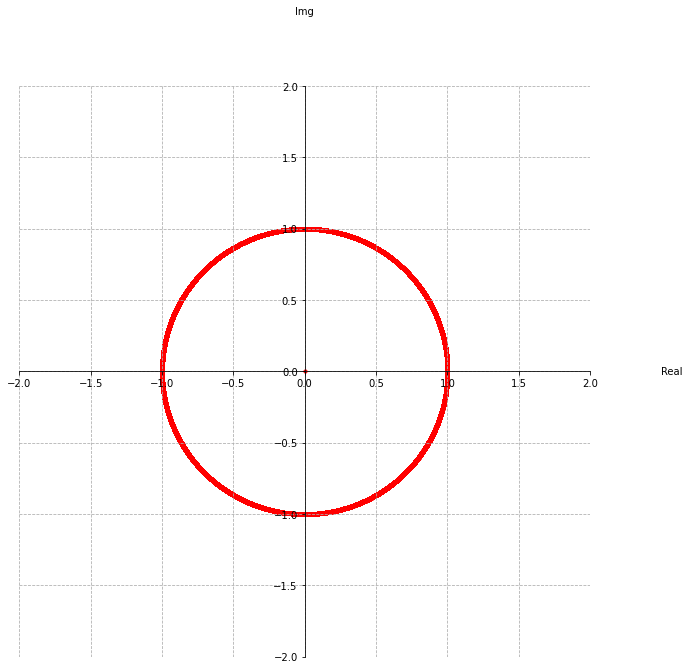

```python
min = -50
max = 50
def get_output_function(a):
  b = np.zeros(a.shape, dtype=complex)
  for i in range(a.shape[0]):
    real_part = a[i].real
    imag_part = a[i].imag
    # Here I wrote the function from the previous description above
    b[i] = math.e**(real_part+1j*imag_part)
  return b
b = get_output_function(get_input_imag_axis(min = min, max = max ))
plot_complex_number(b, -2, 2, -2, 2)
```

# Part C

Graph the line $x = y$ with the $h(x + iy) = e^x(\cos(y) + i \sin(y))$

First I create the real axis that are the inputs. With the `get_input_function`

Then I create the function `get_output_function` $h(x + iy) = e^{x+iy}$ which is the same as $e^x(\cos(y) + i \sin(y))$

This was slightly more difficult. But by plugging in "easy to compute terms" in multiples of $\pi$ we can see a spiral forming after plugging in $x,y=\frac{\pi}{4}, \frac{\pi}{2},\frac{3\pi}{4}, \pi, \frac{5\pi}{4}...$

The spiral forms from the circular nature of the $y$ component and the linear nature of the $x$ component and when combined the circlular radius expands with each increment giving the spiral.

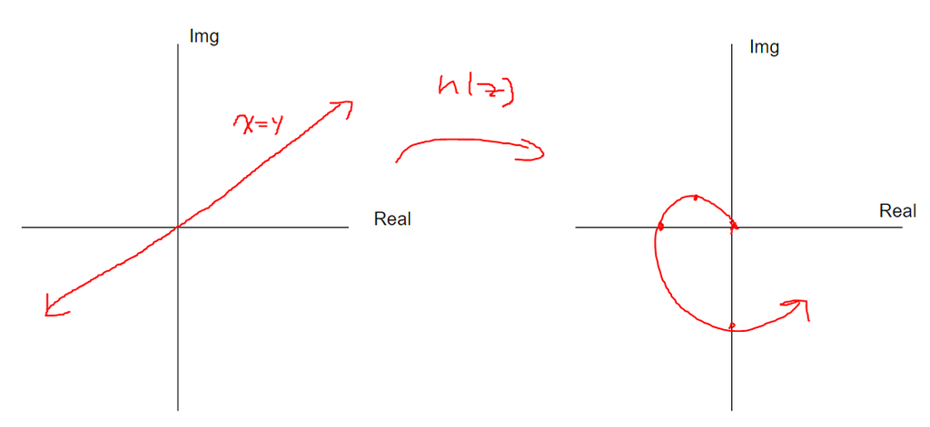

```python
from IPython.display import Image
Image('/content/c_question.PNG')
```

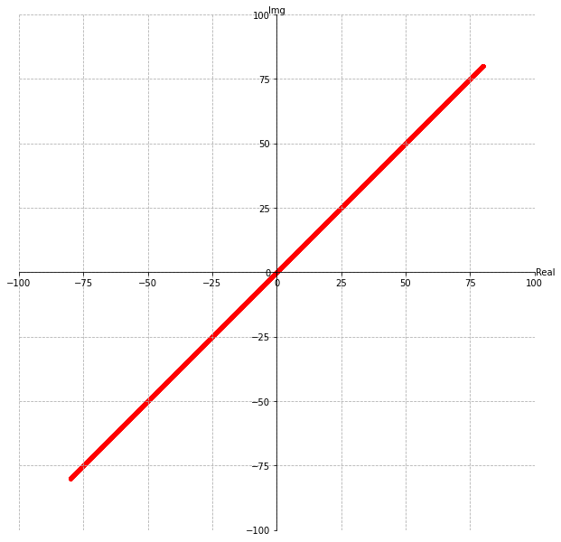

```python
min = -80
max = 80
def get_input_function(min, max):
  a = np.zeros(((max-min)*dx), dtype=complex)
  for i in range(a.shape[0]):
    x_val =  i/dx+min
    # Imaginary part is always zero
    y_val = x_val
    complex_number = x_val + 1j*y_val
    a[i] = complex_number
  return a
a = get_input_function(min = min, max = max )
plot_complex_number(a, -100, 100, -100, 100)
```

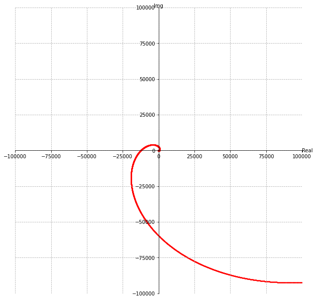

```python
min = -80
max = 80
def get_output_function(a):
  b = np.zeros(a.shape, dtype=complex)
  for i in range(a.shape[0]):
    real_part = a[i].real
    imag_part = a[i].imag
    # Here I wrote the function from the previous description above
    b[i] = math.e**(real_part+1j*imag_part)
  return b
b = get_output_function(get_input_function(min = min, max = max ))
plot_complex_number(b, -100000, 100000, -100000, 100000, dot_size=1)
```

# Part D

Then I create the function `get_output_function` $h(x + iy) = e^{x+iy}$ which is the same as $e^x(\cos(y) + i \sin(y))$

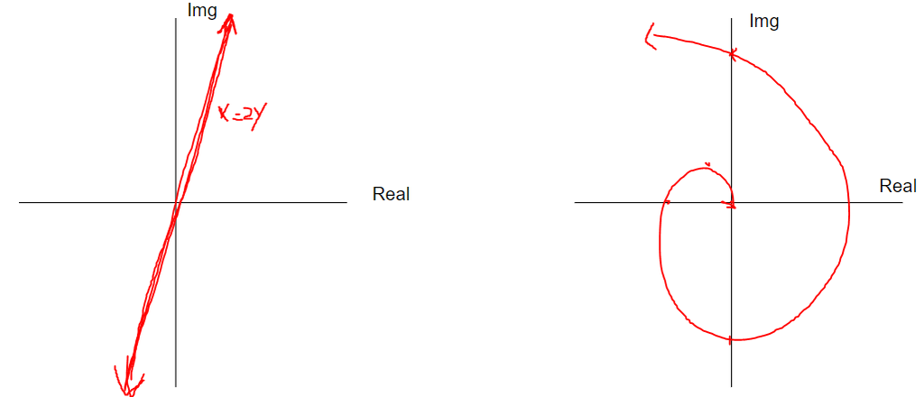

```python
from IPython.display import Image
Image('/content/d_question.PNG')
```

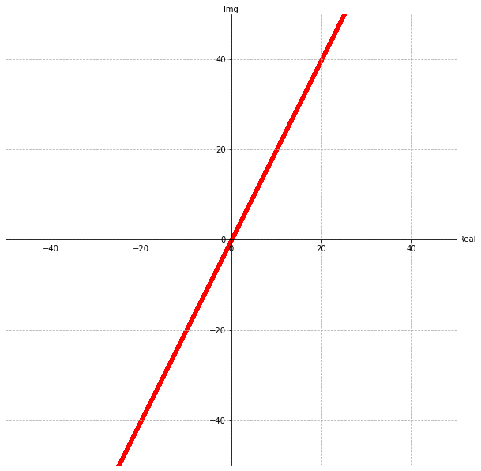

```python
min = -80
max = 80
def get_input_function_2(min, max):
  a = np.zeros(((max-min)*dx), dtype=complex)
  for i in range(a.shape[0]):
    x_val =  i/dx+min
    # Imaginary part is always zero
    y_val = x_val*2
    complex_number = x_val + 1j*y_val
    a[i] = complex_number
  return a
a = get_input_function_2(min = min, max = max )
plot_complex_number(a, -50, 50, -50, 50)
```

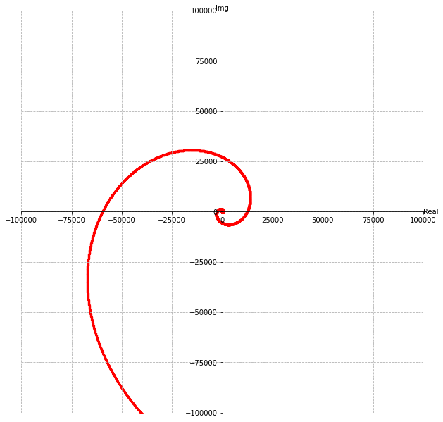

```python
min = -80
max = 80
def get_output_function(a):
  b = np.zeros(a.shape, dtype=complex)
  for i in range(a.shape[0]):
    real_part = a[i].real
    imag_part = a[i].imag
    # Here I wrote the function from the previous description above
    b[i] = math.e**(real_part+1j*imag_part)
  return b
b = get_output_function(get_input_function_2(min = min, max = max ))
plot_complex_number(b, -100000, 100000, -100000, 100000, dot_size=5)
```

# Part E

Graph the line $x = -y$ with the $h(x + iy) = e^x(\cos(y) + i \sin(y))$

First I create the real axis that are the inputs. With the `get_input_function_3` where $x=-y$

Then I create the function `get_output_function` $h(x + iy) = e^{x+iy}$ which is the same as $e^x(\cos(y) + i \sin(y))$

If we were to simplify our expression. $$h(x + iy) = e^x(\cos(y) + i \sin(y))$$ $$h(x + iy) = e^x(\cos(-x) + i \sin(-x))$$ $$h(x + iy) = e^x(\cos(x) - i \sin(-x))$$ Notice its just the complex conjugate $$h(x + iy) = e^x(e^{-ix})$$ $$h(x + iy) = (e^{x-ix})$$ It appears to experience a reflection in the imaginary component. When switching the sign of the vertical component its typically a reflection along the horizontal.

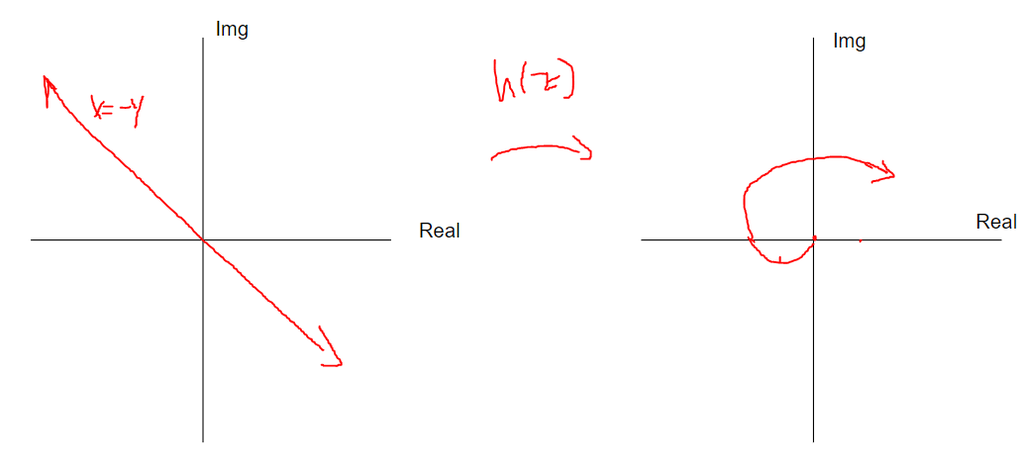

```python
from IPython.display import Image
Image('/content/e_question.PNG')
```

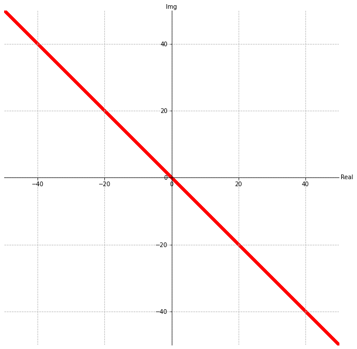

```python
min = -80
max = 80
def get_input_function_3(min, max):
  a = np.zeros(((max-min)*dx), dtype=complex)
  for i in range(a.shape[0]):
    x_val =  i/dx+min
    # Imaginary part is always zero
    y_val = -x_val
    complex_number = x_val + 1j*y_val
    a[i] = complex_number
  return a
a = get_input_function_3(min = min, max = max )
plot_complex_number(a, -50, 50, -50, 50)
```

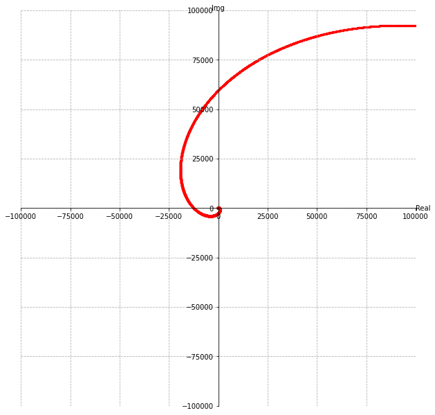

```python
min = -80
max = 80
def get_output_function(a):
  b = np.zeros(a.shape, dtype=complex)
  for i in range(a.shape[0]):
    real_part = a[i].real
    imag_part = a[i].imag
    # Here I wrote the function from the previous description above
    b[i] = math.e**(real_part+1j*imag_part)
  return b
b = get_output_function(get_input_function_3(min = min, max = max ))
plot_complex_number(b, -100000, 100000, -100000, 100000, dot_size=5)
```